# Buffing the dents out of R: Removing R’s frustrating obstacles.

Neil Berg, Ph.D. pre-employed, 84.51

April 27, 2019

https://github.com/neilberg/MeasureCamp2019

## R makes the latest, best-documented high-level analytics tasks simple. *Unfortunately, it also makes simple tasks difficult.*

Why? It has questionable defaults and hidden contexts. Parts of it *evolved* instead of being *designed*.

We will talk about our personal (opinionated!) practices for using R.  
These are largely derived from personal experience answering R questions for marketing and reporting groups.

### Expectations:

#### You will know **some** of these practices.

#### You may not have been exposed to **all** of these topics.

#### You will actively share your thoughts on the topic/practice/experience (at end)!

#### You will know workarounds to make your R experience capable and frustration-free.

[figure not shown]

Change frustration into awesomeness.

## Outline

### R is not quite ready when you get it.

- “R is so mathy that it is hard to interact with”
- General startups: stringsAsFactors and scipen
- Source in or set as Rprofile

### R makes some simple things more complicated than they should be.

- “I can’t copy and paste my output!”
- “I want to output to Excel” (openxlsx)

### R is tuned for compatiblity over speed.

- For loops are usually fine.
- How to get around RAM issues.
- There are many ways to increase the speed of R.

### “I gave up on R because it made me angry”

- “R isn’t performing the function correctly!”
- Rstudio has fixed most of your problems recently
- The future of R is bright

# How R is a bit broken when you install it

[figure not shown]

Sometimes you need to help yourself.

## You will likely need to define startup options

## “R is so mathy that it is hard to interact with”: stringsAsFactors

If you create an R dataframe, it will assume that your string entry is a factor.

“#> invalid factor level, NA generated”

```r
options(stringsAsFactors = FALSE)
```

## “Who likes scientific notation?”: scientific notation penalty

##### It’s running the default, which limits you to 5 digits.

```r
options(scipen = NULL)
print(100000)
```

```
## [1] 1e+05
```

```r
options(scipen = 999)
print(100000)
```

```
## [1] 100000
```

## What you want as your startup file

These are worthy of:

- 1. being in your .RProfile or
- 2. In an sourced-in script that you cite before all of your programs or
- 3. just throw them at the top of your scripts

```r
options(stringsAsFactors = FALSE)
options(scipen = 999)
```

### What’s a .RProfile?

Your .Rprofile is an R script that runs each time R runs and they can be found within R_HOME, HOME and the project’s home directory.  
Find them with getwd().

### How to source-in a file?

This example is what I evolved into in a typical office environment.

source(“S:/jsmith/loadlibraries.R”) # housed on shared network drive – holds all library()s and options

source(“U:/jsmith/loadfunctions.R”) # housed in personal folder to keep obscured from network

source(“U:/jsmith/sqlconnectscript.R”) # housed in personal folder to keep obscured from network

## R makes some simple things really hard.

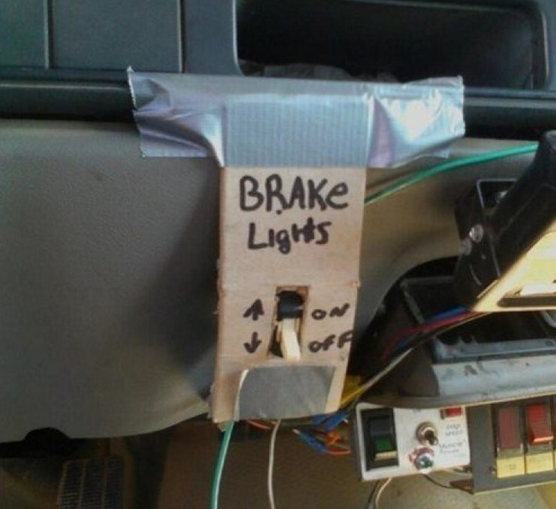

Simple things need to work, even if there are reasons they need workarounds.

## “I can’t copy and paste my output!”

You see what you want to copy from the output window, but you copy without retaining columns.

```r
df <- data.frame(1:5, c(2,3,2,4,6), c(2,3,1,9,6), c(2,3,2,4,9), c(2,3,2,4,7), c(2,3,2,4,8))
cor(df)
```

```
##                       X1.5 c.2..3..2..4..6. c.2..3..1..9..6.
## X1.5             1.0000000        0.8504201        0.6767155
## c.2..3..2..4..6. 0.8504201        1.0000000        0.7125145
## c.2..3..1..9..6. 0.6767155        0.7125145        1.0000000
## c.2..3..2..4..9. 0.8134892        0.9736551        0.5505008
## c.2..3..2..4..7. 0.8387421        0.9942735        0.6413028
## c.2..3..2..4..8. 0.8255008        0.9840315        0.5893232
##                  c.2..3..2..4..9. c.2..3..2..4..7. c.2..3..2..4..8.
## X1.5                    0.8134892        0.8387421        0.8255008
## c.2..3..2..4..6.        0.9736551        0.9942735        0.9840315
## c.2..3..1..9..6.        0.5505008        0.6413028        0.5893232
## c.2..3..2..4..9.        1.0000000        0.9924475        0.9986946
## c.2..3..2..4..7.        0.9924475        1.0000000        0.9974179
## c.2..3..2..4..8.        0.9986946        0.9974179        1.0000000
```

Option 1: Don’t copy and paste, just output into CSV/TSV/xlsx  
If **not** huge, use tidyverse: write_tsv or write_csv  
If **huge**, use data.table::fwrite

Option 2: R2HTML

```r
df <- data.frame(1:5, c(2,3,2,4,6), c(2,3,1,9,6), c(2,3,2,4,9), c(2,3,2,4,7), c(2,3,2,4,8))
library(R2HTML)
HTMLStart(outdir="c:/tmprdata/", file="myreport1", extension="html",
          echo=FALSE, HTMLframe=TRUE)
```

```
##
##  *** Output redirected to directory:  c:/tmprdata/
##  *** Use HTMLStop() to end redirection.
```

```
## [1] TRUE
```

```r
cor(df)
```

```
##                       X1.5 c.2..3..2..4..6. c.2..3..1..9..6.
## X1.5             1.0000000        0.8504201        0.6767155
## c.2..3..2..4..6. 0.8504201        1.0000000        0.7125145
## c.2..3..1..9..6. 0.6767155        0.7125145        1.0000000
## c.2..3..2..4..9. 0.8134892        0.9736551        0.5505008
## c.2..3..2..4..7. 0.8387421        0.9942735        0.6413028
## c.2..3..2..4..8. 0.8255008        0.9840315        0.5893232
##                  c.2..3..2..4..9. c.2..3..2..4..7. c.2..3..2..4..8.
## X1.5                    0.8134892        0.8387421        0.8255008
## c.2..3..2..4..6.        0.9736551        0.9942735        0.9840315
## c.2..3..1..9..6.        0.5505008        0.6413028        0.5893232
## c.2..3..2..4..9.        1.0000000        0.9924475        0.9986946
## c.2..3..2..4..7.        0.9924475        1.0000000        0.9974179
## c.2..3..2..4..8.        0.9986946        0.9974179        1.0000000
```

```r
HTMLStop()
```

```
## [1] "c:/tmprdata//myreport1_main.html"
```

file:///C:/tmprdata/myreport1.html

[figure not shown]

Copy and paste now work normally.

## “Forget all that complicated stuff, this report needs to read/write from Excel”

Most-Googled packages: *xlsReadWrite, xlsx, writexl, XLConnect, Readxl* are options but use:

openxlsx does it all: read/ write, uses tabs. Can even apply excel styles (e.g., commas, dollars, percentages)

Aside: Reading in dates rom Excel? Excel dates are the number of days since Dec 30, 1899.  
Get to a real date in R using this: as.Date(42705, origin = “1899-12-30”)

## R and speed

[figure not shown]

It really can go fast, you may just have to change a few things.

### “I run out of RAM using R”

tidyverse functions don’t “modify in place,” they copy and then (once verified as good) delete the old. This takes 2x the space! - Use a totally different package, like data.table, that is built for speed and modifies in place.

### “Are there better versions of R?” (yes, there are)

Vanilla R is the slowest R. It assumes your CPU has no math coprocessing. Matrix manipulations cannot get slower.  
a - Speed up your processing. Try Microsoft R Open for BLAS (basic linear algebra subprograms) + Intel math kernel libraries. Other BLAS packs (OpenBLAS for general CPUs, NVBLAS for NVidia GPUs) are available too.

b - Speed up your data structures. data.table has a lot of efficiency tweaks.

c - Speed up your data IO. Big data solutions that abstract from/with R: Spark, RevolutionR/ScaleR/MRS/AzureR/Rocker/H2O.

d - all of the above. Use MRO with data.table. Data IO is constantly changing, but can be significant.

e - “future” package (in development now) for de-serializing programs (or doParallel or foreach).

## One last section….“I gave up on R because it made me angry”

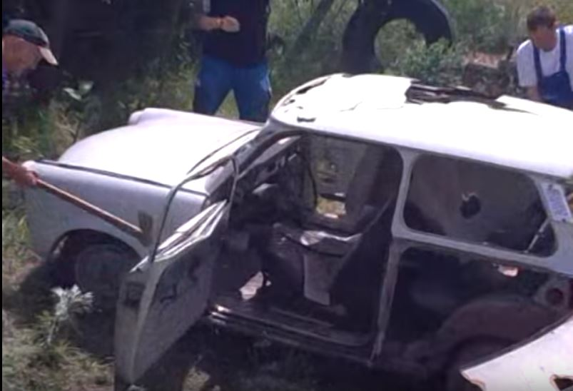

Don’t hit it with an ax yet. Things are already better.

### For Windows non-admin installations, install to “C:" (or similar, NOT Program Files) or you are entering a world of pain.

### “R isn’t performing the function correctly!” “It ran yesterday.”

#### Be explicit about which library’s function you want!

Do this: **data1 %>% dplyr::select(col1)**  
Not this: **data1 %>% select(col1)**

Code breaks when two loaded packages share a function name.

6,601 results for functions named “select”  
https://www.rdocumentation.org/search?q=select&latest=1

### R has improved since 2016!

Rstudio V1.x  
- Accidentally printing a huge output will no longer crash/cause issues  
- No longer freezes, job queuing is improved in RStudio 1.2  
- Lots of added features (environment windows, connections, console, etc)

tidyverse (now one library) has taken over.  
Forget about the first package suggested by Google. Get the first package suggested by rstudio. It will likely be tidyverse.

Lots of improvements to applying functions to data at scale  
apply functions are still neato, but you can iterate and use lists better than ever (purrr, broom, etc)

New and useful for time series data: tsibble

## dRive in style. Be capable, fast, and frustration-free!

https://github.com/neilberg/MeasureCamp2019

[figure not shown]

## Summary

- A few lines of startup code can truly help.
- A few packages remove pain points and create simpler operation.
- There are a range of ways to make R faster. It is worth evaluating which are best for your situation.
- RStudio has been doing a great job of refining R.